# MSNE

with Connor T. Wiegand

## Last Time

### Updated Definition

- Def [Version 2.0]: A strategy is said to be **Never a Best Response** provided that it is never a component of a player’s best response function — *taking into account mixed strategies*
  - In other words, a strategy is an NBR provided that it isn’t in the upper envelope of an agent’s expected payoff graph
- For the updated definition, I will also use NBR interchangeably with **non-rationalizable**
  - We could say an agent’s strategy is rationalizable if it *is* in ever a component of the agent’s best response function

### NBR Example

- The game:
- We have seen this game before. Recall:
  - $BR_1(X)=F$
  - $BR_1(Y)=G$

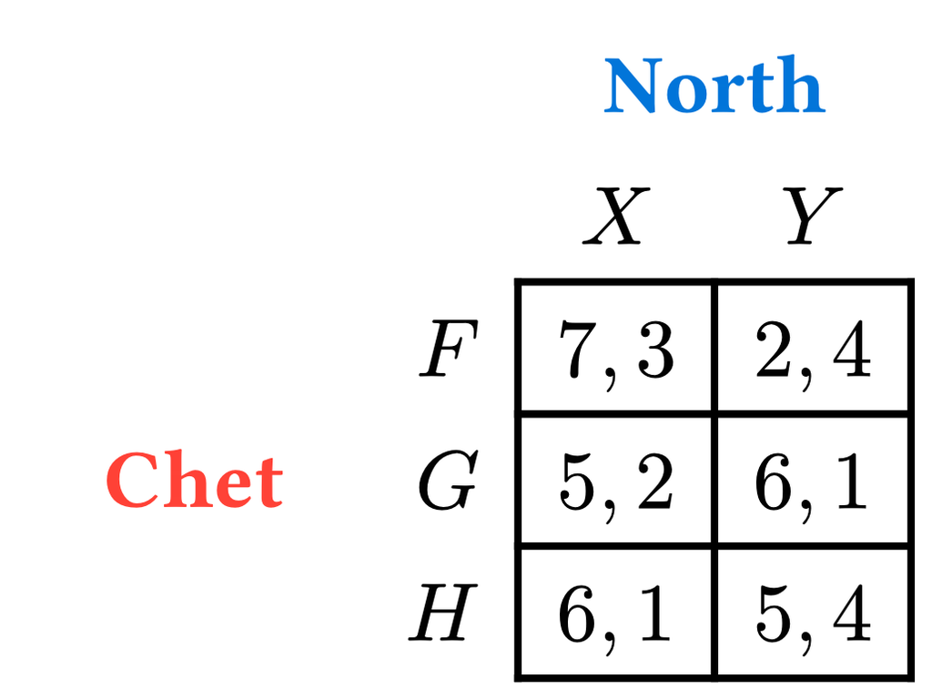

- It is tempting to want to say that $H$ is Never a Best Response, because player 1 would always rather play something other than $H$ in response to a pure strategy
  - Should player 1 ever play $H$?

### NBR Example – player 1

- Suppose player 2 is playing $\tau=qX+(1-q)Y$
- Game
- E.P. Graph
- Upper Envelope
- BR function

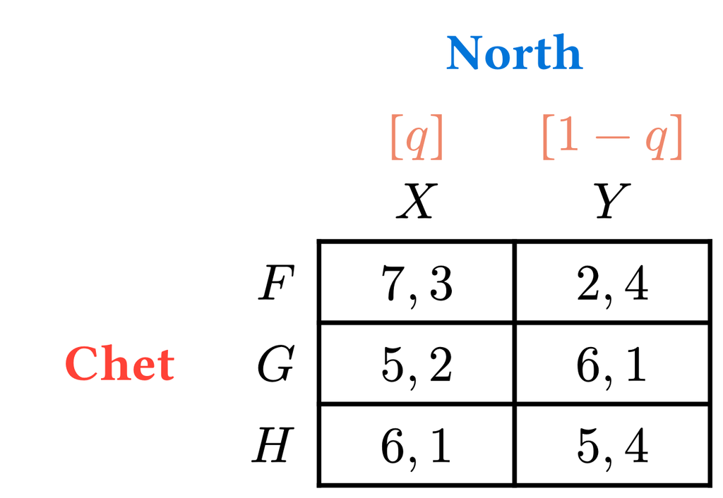

[interactive chart not shown]

$$BR_1(q)=
\begin{cases}
G & q < q_1^*\\
{G, H} & q = q_1^*\\
H & q_1^*\le q \le q_2^*\\
{H, F} & q = q_2^*\\
F & q>q_2^*
\end{cases}$$

### What about player 2?

- Note: intersection points in the upper envelope of an expected payoff graph reveal *candidates* for MSNE
  - But not every intersection in the upper envelope is guaranteed to be a MSNE
- To see this, consider the previous example
  - We know player 1 will never play a *totally* mixed strategy: if they were to mix, they’d mix between $G$ and $H$ or $F$ and $H$
  - Let’s look at player 2’s expected payoff graphs for each of the following mixed strategies player 1 may rationally play
    - $\sigma_1=pG+(1-p)H$
    - $\sigma_2=rF+(1-r)H$

### Player 2’s E.P. graphs

- Assume player 1 is playing $\sigma_1=pG+(1-p)H$
- Game
- E.P. Graph
- BR function

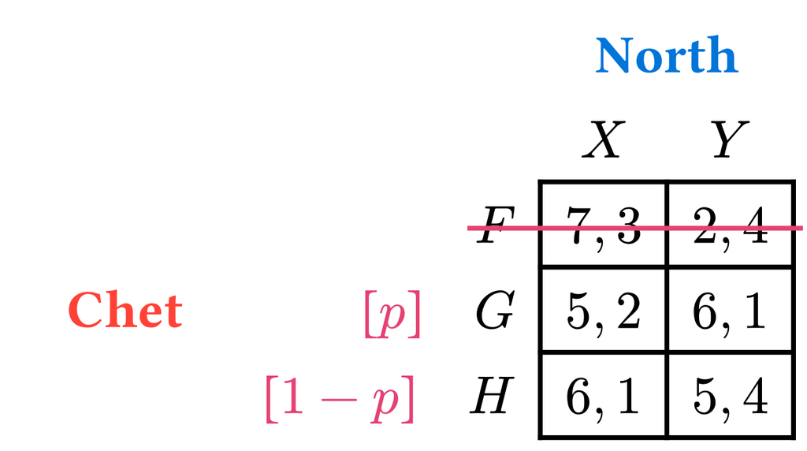

[interactive chart not shown]

$$BR_2(\sigma_1(p))=
\begin{cases}
Y & p < p^*\\
{X, Y} & p = p^*\\
X & p>p^*
\end{cases}$$

### Player 2’s E.P. graphs (cont.)

- Assume player 1 is playing $\sigma_2=rF+(1-r)H$
- Game
- E.P. Graph
- BR function
- Notes
- Reasoning

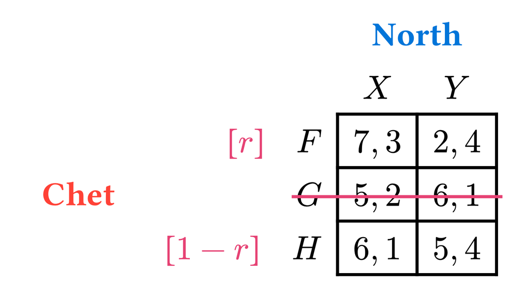

[interactive chart not shown]

$$BR_2(\sigma_2(r))=
\begin{cases}
Y & r \in [0,1]
\end{cases}$$

- If player 1 is playing $\sigma_2=rF+(1-r)H$, then player 2 should always play $Y$
- We know there is no PSNE, so this will lead to a loop of best responses which does not converge to a NE (see “Reasoning”{.alert2} for details)
- Therefore, there is **no** MSNE where player 1 plays $\sigma_2$
- If player 1 is playing $\sigma_2=rF+(1-r)H$, then player 2 should always play $Y$
  - If player 2 is playing $Y$, player 1 should play $G$
  - $\implies$ player 2 should play $X$
  - $\implies$ player 1 should play $F$
  - $\implies$ player 2 should play $Y$
  - $\implies$ …

### MSNE in 3x2 Example

- So… we know we are looking for a single MSNE when player 1 is playing $\sigma_1$ (which I will now call $\sigma$) and player 2 is playing $\tau$
- Game (tau)
- Step 1.0
- Step 1.1
- Game (sigma)
- Step 2.0
- Step 2.1
- MSNE

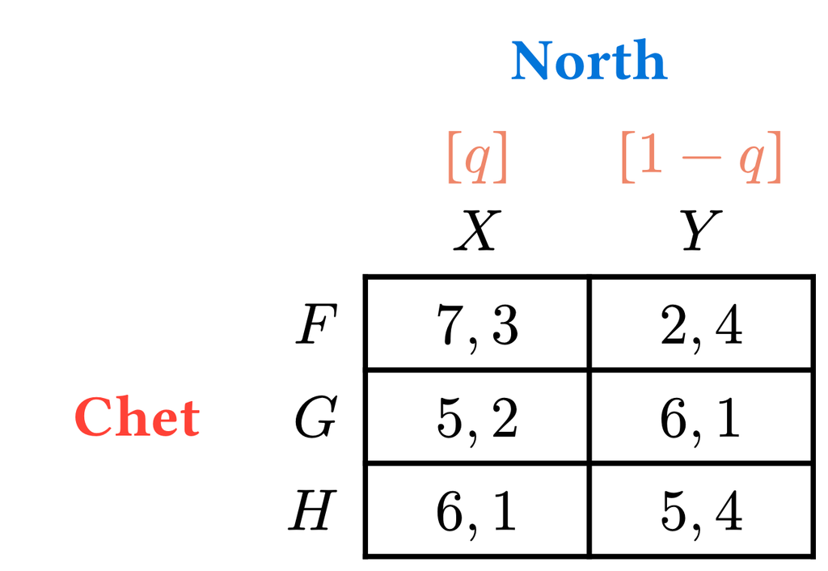

- Assume player 2 is playing $\tau=qX+(1-q)Y$
- Then, player 1 gets
  - $u_1(G)=5q+6(1-q)$
  - $u_1(H)=6q+5(1-q)$
- Player 1 will mix between $G$ and $H$ when they are indifferent between these payoffs

$$\begin{align*}
5q+6(1-q) & = 6q+5(1-q) \\
\implies q^* =q_1^* &= \frac{1}{2}
\end{align*}$$

- *Remark*: to be careful, we may also want to verify that $u_1(G)$$^\dagger$ yields a greater payoff $u_1(F)$ when $p=1/2$, but I won’t ask you to do this
  - $\dagger$ : Or $u_1(H)$. Or $u_1(\sigma_1)$. They are all equal by construction.

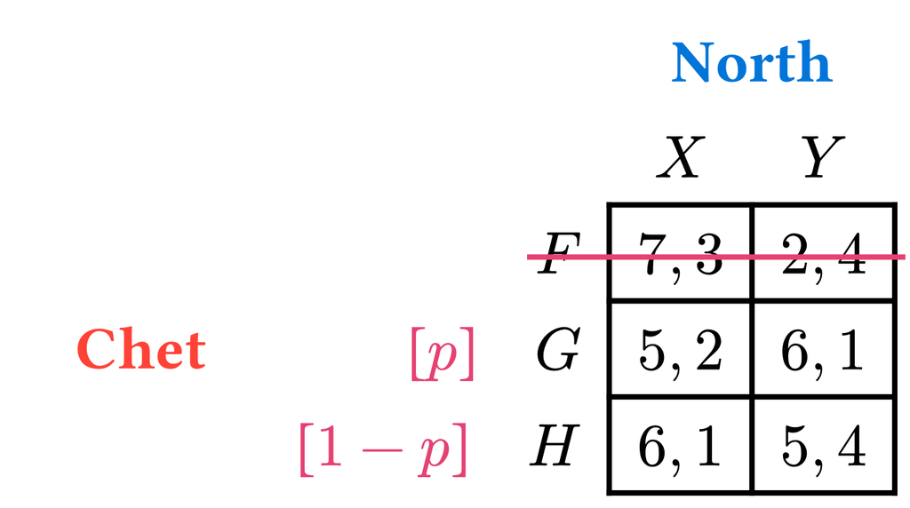

- Assume player 1 is playing $\sigma=pG+(1-p)H$
- Then, player 1 gets
  - $u_2(X)=2p+(1-p)=1+p$
  - $u_2(Y)=p+4(1-p)=4-3p$
- Player 2 will mix between $X$ and $Y$ when they are indifferent between these payoffs

$$\begin{align*}
1+p & = 4-3p \\
4p &= 3\\
\implies p^* &= \frac{3}{4}
\end{align*}$$

Therefore, our MSNE is

$$\left\{\frac{3}{4}G+\frac{1}{4}H, \frac{1}{2}X+\frac{1}{2}Y\right\}\\$$
or
$$\{\sigma_1(3/4), \tau(1/2)\}$$
or
$$((F,G,H); (X,Y)) \rightarrow \left\{\left(0,\frac{3}{4}, \frac{1}{4}\right); \left(\frac{1}{2}, \frac{1}{2}\right)\right\}$$

## Graphing Best Responses

### Recall: BoS

- Let’s return to the BoS instance we saw on Monday
- Game
- Player 1
- Player 2
- MSNE
- BR functions

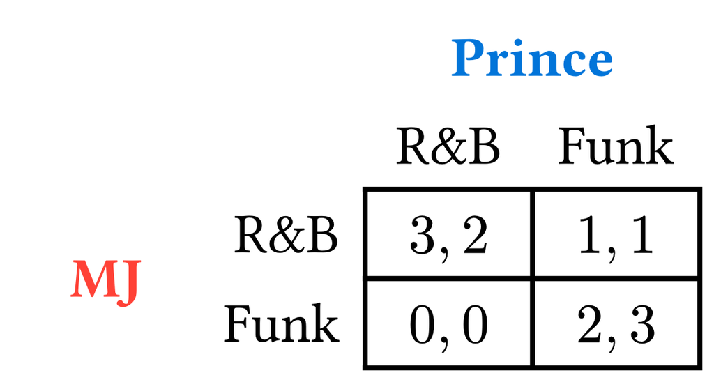

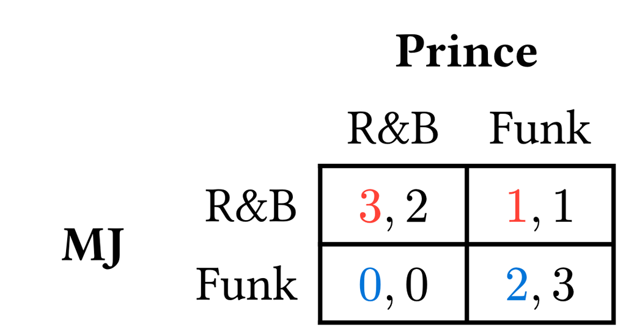

[interactive chart not shown]

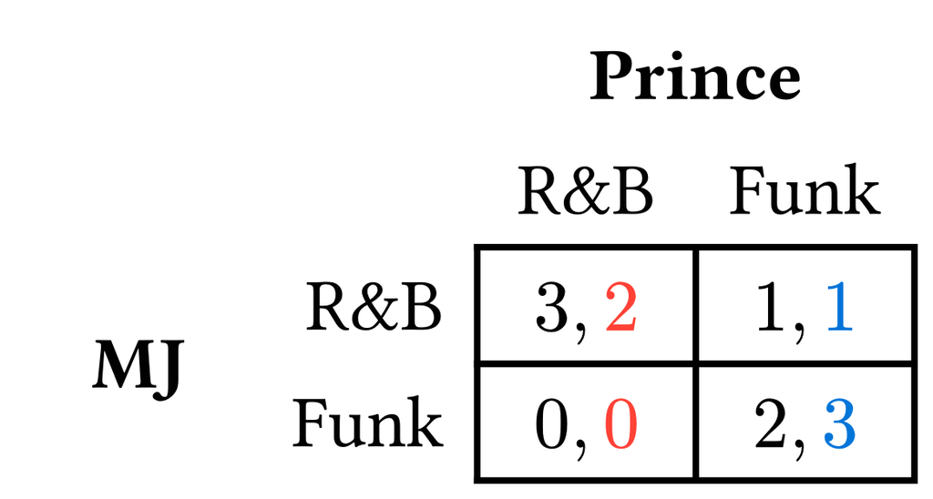

[interactive chart not shown]

- Just as reminder: we found that the MSNE in this game was

  $$((R, F); (R, F))\rightarrow\left\{\left(\frac{3}{4}, \frac{1}{4}\right); \left(\frac{1}{4}, \frac{3}{4}\right)\right\}$$
- This is not what I want to focus on
- From the expected payoff graphs – namely, from the upper envelopes – we found the following BR functions for each player:
  $$BR_1(\tau(q))=
  \begin{cases}
  F & q<0.25\\
  \{R,F\} & q=0.25\\
  R & q>0.25
  \end{cases}%
  \hspace{2em}
  BR_2(\sigma(p))=
  \begin{cases}
  F & p<0.75\\
  \{R,F\} & p=0.75\\
  R & q>0.75
  \end{cases}%$$
- Recall that we assume player 1 is playing $\sigma(p)=pR+(1-p)F$ and player 2 is playing $\tau(q)=qR+(1-q)F$
- *Idea*: let’s rewrite the BR functions as written above in terms of each player’s own strategy
  - Put another way: convert the BR functions to be in terms of the probability parameters

### Converting BR functions

- We assume player 1 is playing $\sigma(p)=pR+(1-p)F$ and player 2 is playing $\tau(q)=qR+(1-q)F$
  $$BR_1(\tau(q))=
  \begin{cases}
  F & q<0.25\\
  \{R,F\} & q=0.25\\
  R & q>0.25
  \end{cases}%
  \hspace{2em}
  BR_2(\sigma(p))=
  \begin{cases}
  F & p<0.75\\
  \{R,F\} & p=0.75\\
  R & q>0.75
  \end{cases}%$$
- Idea
- Example
- Conversion
- Let’s rewrite the BR functions as written above in terms of each player’s own strategy
- Put another way: convert the BR functions to be in terms of the probability parameters
- Player 1 playing $F$ means playing $\sigma(0)=0R+(1-0)F$, so $F$ corresponds to $p=0$ for player 1
- Player 1 playing $R$ means playing $\sigma(1)=1R+(1-1)F$, so $R$ corresponds to $p=1$ for player 1
- $\{R,F\}$ means player 1 is indifferent between $R$ and $F$ – and everything in between – so this corresponds to $p\in[0,1]$
- For this game specifically, these correspondences are symmetric for player 2
- Using the strategy definitions, our BR functions can be converted into the following

  $$p^{BR}(\tau(q)) =
  \begin{cases}
  0 & q<0.25\\
  [0,1] & q=0.25\\
  1 & q>0.25
  \end{cases}%
  \hspace{2em}
  q^{BR}(\sigma(p))=
  \begin{cases}
  0 & p<0.75\\
  [0,1] & p=0.75\\
  1 & q>0.75
  \end{cases}%$$

### Best Response Graph

- Now, we have numeric BR functions

  $$p^{BR}(\tau(q)) =
  \begin{cases}
  0 & q<0.25\\
  [0,1] & q=0.25\\
  1 & q>0.25
  \end{cases}%
  \hspace{2em}
  q^{BR}(\sigma(p))=
  \begin{cases}
  0 & p<0.75\\
  [0,1] & p=0.75\\
  1 & q>0.75
  \end{cases}%$$
- Let’s plot them in $pq$-space

### Player 1

$$p^{BR}(\tau(q)) =
\begin{cases}
0 & q<0.25\\
[0,1] & q=0.25\\
1 & q>0.25
\end{cases}%$$

[interactive chart not shown]

- How to read:
  - “When $q$ lives in $[0, 0.25]$, $p=0$”
  - “When $q$ lives in $[0.25, 1]$, $p=1$”
  - “When $q$ exactly equals $0.25$, $p$ can take on any value in $[0,1]$”

### Player 2

$$q^{BR}(\sigma(p))=
\begin{cases}
0 & p<0.75\\
[0,1] & p=0.75\\
1 & q>0.75
\end{cases}$$

[interactive chart not shown]

- How to read:
  - “When $p$ lives in $[0, 0.75]$, $q=0$”
  - “When $p$ lives in $[0.75, 1]$, $q=1$”
  - “When $p$ exactly equals $0.75$, $q$ can take on any value in $[0,1]$”

### Altogether

- Now, let’s combine these graphs
- What are the circles?
  - Intersections of best response functions
    - Nash Equilibria!

[interactive chart not shown]

### So many flavors!

- Game
- BR Graph
- MSNE
- Here is another example that we don’t have time for:

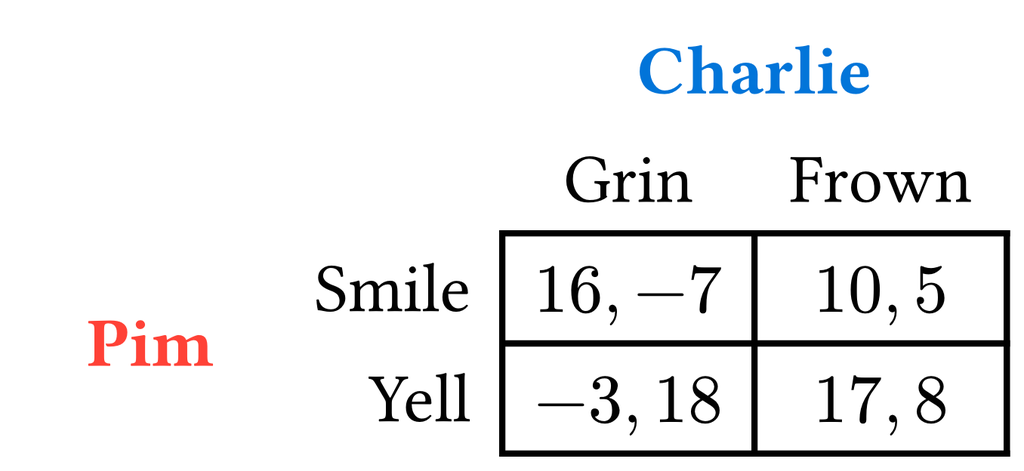

- The best response graph for this game is shown here:

[interactive chart not shown]

## Practice

### Link

- Here<sup>1</sup> is the link to MSNE practice from UO PhD graduate Ethan Holdahl: https://ethanholdahl.shinyapps.io/Game-Theory-Tools/
[^1]: Also on Canvas
- Blank
- Blank
- Blank
- Blank
- Blank